# The t-distribution

Mike Hitchman

10/20/2021

### The Scene

The central limit theorem for means says that if we draw an independent sample of size $n$ from a distribution that has population mean $\mu$ and standard deviation $\sigma$ then, assuming $n$ is sufficiently large, the distribution for $\bar{x}$ is approximately normal with mean = $\mu$ and standard deviation = $\sigma/\sqrt{n}$. That is,
$$\bar{x} \sim N\left(\mu,\frac{\sigma}{\sqrt{n}}\right).$$

This means that if we gather a random sample of size $n$ and compute the sample mean $\bar{x}$, the test statistic
$$z = \frac{\bar{x}-\mu}{\sigma/\sqrt{n}}$$
lives in a standard normal distribution $N(0,1)$.
Knowing this, we can make reasoned arguments about the value of an unknown population mean based on analysis of a sample mean $\bar{x}$. For instance, a 95% confidence interval for $\mu$ based on a sample mean $\bar{x}$ is given by:
$$\bar{x} \pm 1.96 \cdot \frac{\sigma}{\sqrt{n}}.$$

But there’s one big catch. Computing the $z$ statistic or finding the confidence interval requires us to know the value of the population standard deviation $\sigma$. What if we don’t know $\sigma$?

This is a fair, important question because, in practice, we rarely know $\sigma$.

Our workaround is this: When we gather an independent sample, we use $s$, the sample standard deviation, as an estimate for $\sigma$.

There is a measurable cost to using this approximation, however, because there will be variation from sample to sample in the value of $s$. The goal of this page is to account for this cost.

If we replace $\sigma$ with $s$, we call the revised statistic a **t statistic**:
$$t = \frac{\bar{x}-\mu}{s/\sqrt{n}}.$$
The t statistic does not live in a standard normal distribution. The distribution of this statistic is more like a bell-curve with fatter tails. The actual model for this type of distribution is called a **t-distribution**.

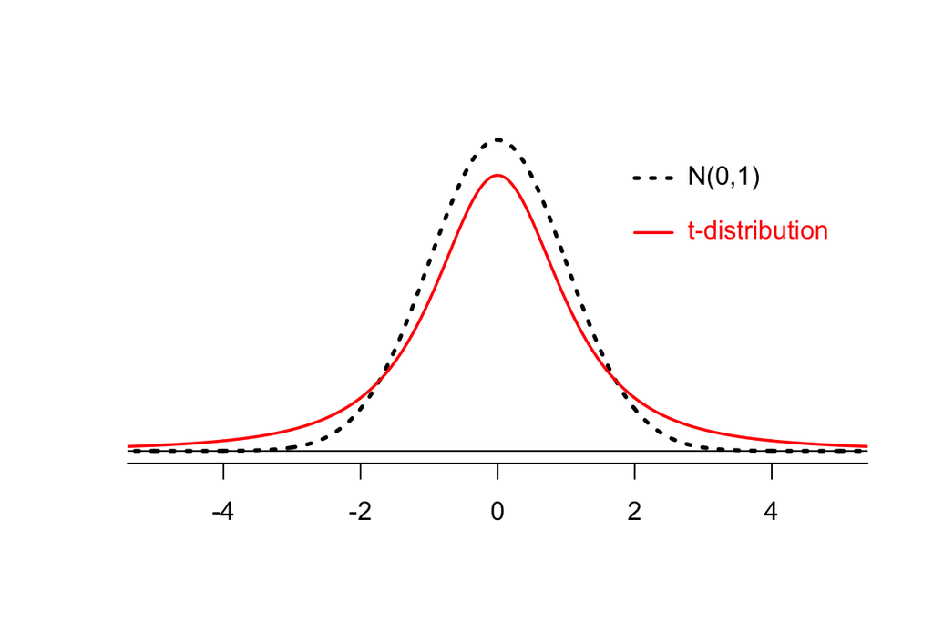

There is actually an entire, infinite family of t-distributions, one for each positive integer. We refer to a particular t-distribution by this integer, which by convention is called the **degrees of freedom.**

Below are plots for t-distributions with 2, 8, and 20 degrees of freedom, which we denote as $t_2, t_8, t_{20}$. For comparison, the plot also contains the standard normal distribution $N(0,1)$.

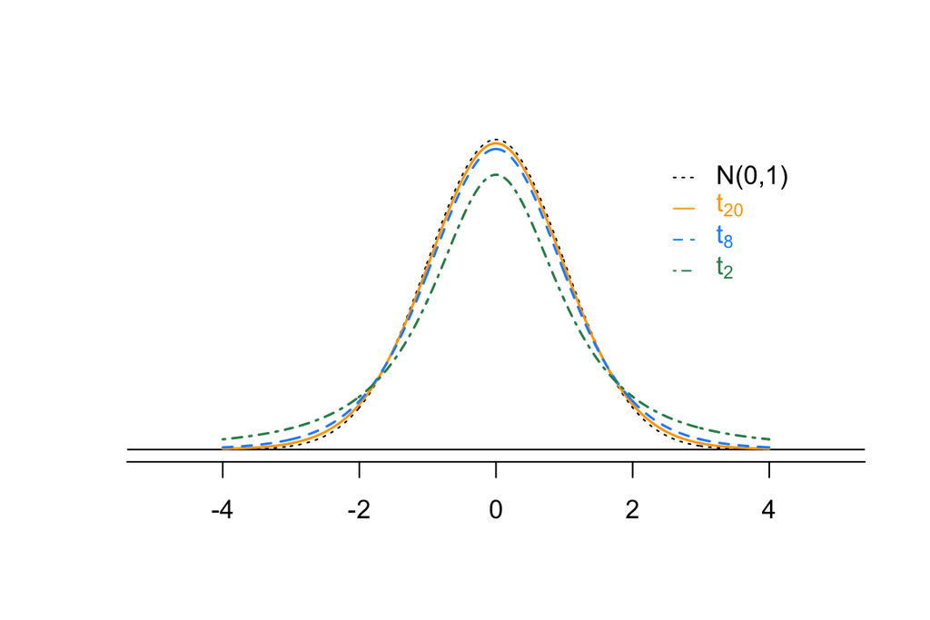

We remark that the larger the degrees of freedom number (df) gets, the closer the distribution $t_{\text{df}}$ gets to $N(0,1)$.

### Comparing z-scores and t-scores

Let’s take a minute to dive into the difference between t-scores and z-scores.

The code below makes many repetitions (20,000) of the following process:

1. Draw a sample of size $n=5$ from $N(10,2)$, a normal distribution with mean $\mu = 10$ and standard deviation $\sigma = 2$.
2. Record the sample mean $\bar{x}$ and sample standard deviation $s$ of this sample.
3. Determines the z statistic
   $$z = \frac{\bar{x}-10}{2/\sqrt{5}}.$$
4. Determine the t statistic
   $$t = \frac{\bar{x}-10}{s/\sqrt{5}}.$$

The code also records the 20,000 $z$-scores and the 20,000 $t$-scores in the vectors `z_scores` and `t_scores`, respectively.

```r
trials<-20000
n=5
z_scores=c()
t_scores=c()
for (i in 1:trials){
  samp <- rnorm(n,mean=10,sd = 2)
  xbar <- mean(samp)
  s <- sd(samp)
  z <- (xbar-10)/(2/sqrt(n))
  t <- (xbar-10)/(s/sqrt(n))
  z_scores=c(z_scores,z)
  t_scores=c(t_scores,t)
  }
```

Below are histogram density plots of the z-scores and t-scores produced in the code above. The $z$ scores live in a $N(0,1)$ distribution, and the $t$-scores live in a $t_4$ distribution. Notice the t-distribution has fatter tails.

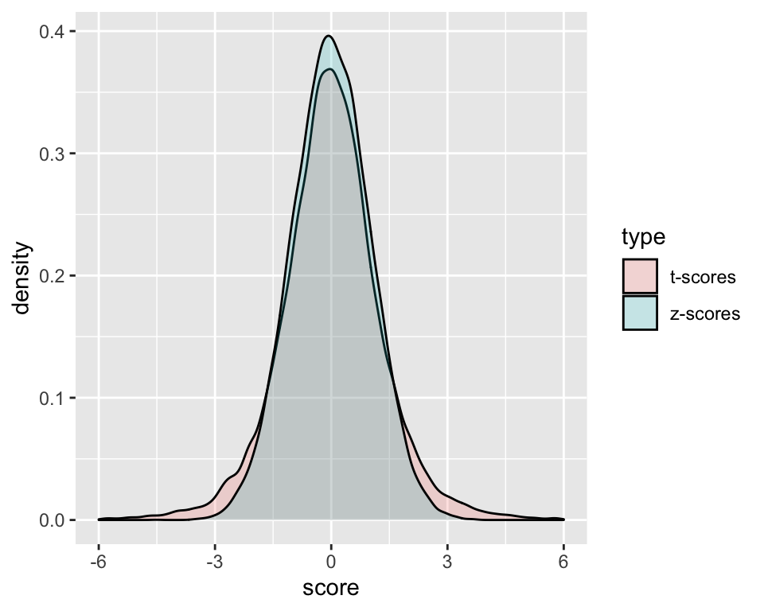

We can also check the histogram of t-scores against the N(0,1) density curve, and against the $t_4$ density curve. Which density curve is the better model?

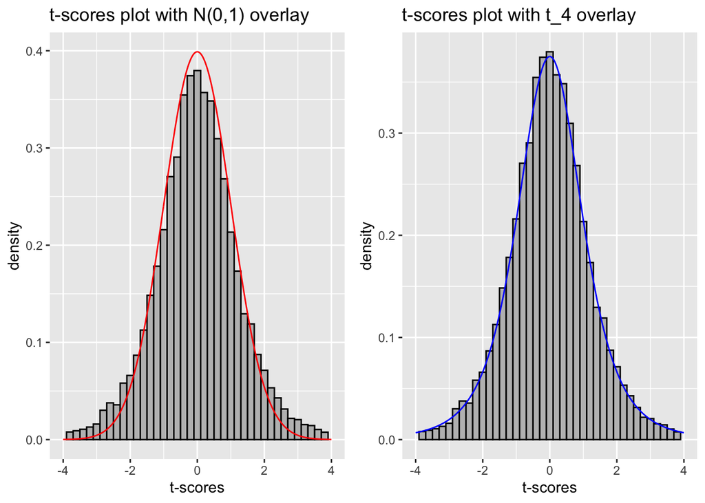

### Notes

1. If the underlying distribution we’re drawing from is normal, as was the case in the simulation above, then the distribution for $t=\frac{\bar{x}-\mu}{s/\sqrt{n}}$ is precisely a t-distribution, regardless of the sample size.
2. If the underlying distribution we’re drawing from is NOT normal, as in the case below, the t-distribution is a reasonable model as long as the sample size is fairly large (usually at least 30) and no extreme values are present.

### Drawing from a non-normal distribution

Suppose we are drawing from a skewed right population such as the one represented in the histogram below.

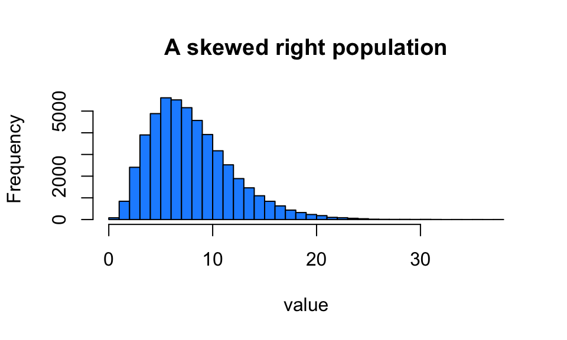

```r
pop <- rchisq(50000,df=8)
hist(pop,breaks=30,main="A skewed right population",col="dodgerblue",xlab="value")
```

Let’s take a sample of size $n = 5$ from this population, determine $\bar{x}$, $s$, and then compute
$$t = \frac{\bar{x}-\mu}{s/\sqrt{n}},$$
where $\mu$ = `mean(pop)`=7.9803691. Then we repeat this 10,000 times and plot the 10,000 t-scores.

```r
trials<-10000
mu = mean(pop)
n = 5
t_scores=c()
for (i in 1:trials){
  samp <- sample(pop,n)
  xbar <- mean(samp)
  s <- sd(samp)
  t <- (xbar-mu)/(s/sqrt(n))
 t_scores=c(t_scores,t)
  }
```

If we stack these t-scores into a histogram, is the $t_4$ density curve a good fit?

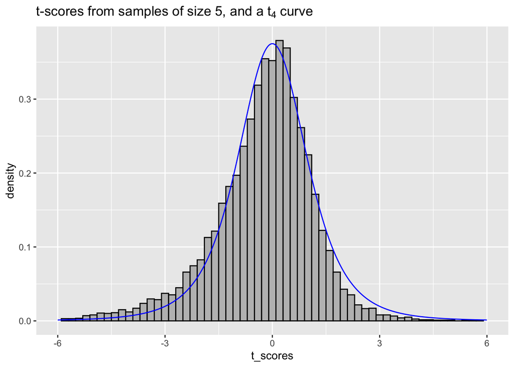

```r
# make a plot
tscore <- data.frame(t_scores)
p <- ggplot(tscore) +
  geom_histogram(aes(x = t_scores, y = ..density..),
                 binwidth = .2, fill = "grey", color = "black")
x <- seq(-6,6,.01)
y <- dt(x,n-1)
df<-data.frame(x,y)
p + geom_line(data = df, aes(x = x, y = y), color = "blue") + xlim(-6,6) +
  ggtitle(expression(paste("t-scores from samples of size 5, and a ", t[4]," curve")))
```

Not so snug. How about we repeat this game but with a larger sample size, say $n = 30$:

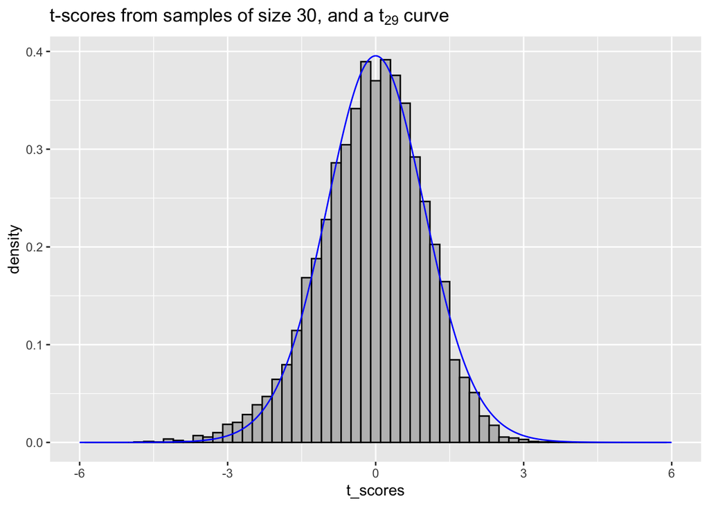

```r
trials<-10000
mu = mean(pop)
n = 30
t_scores=c()
for (i in 1:trials){
  samp <- sample(pop,n)
  xbar <- mean(samp)
  s <- sd(samp)
  t <- (xbar-mu)/(s/sqrt(n))
 t_scores=c(t_scores,t)
  }

# make a plot
tscore <- data.frame(t_scores)
p <- ggplot(tscore) +
  geom_histogram(aes(x = t_scores, y = ..density..),
                 binwidth = .2, fill = "grey", color = "black")
x <- seq(-6,6,.01)
y <- dt(x,n-1)
df<-data.frame(x,y)
p + geom_line(data = df, aes(x = x, y = y), color = "blue") + xlim(-6,6) +
  ggtitle(expression(paste("t-scores from samples of size 30, and a ", t[29]," curve")))
```

Better. How about larger still, say $n = 100$?

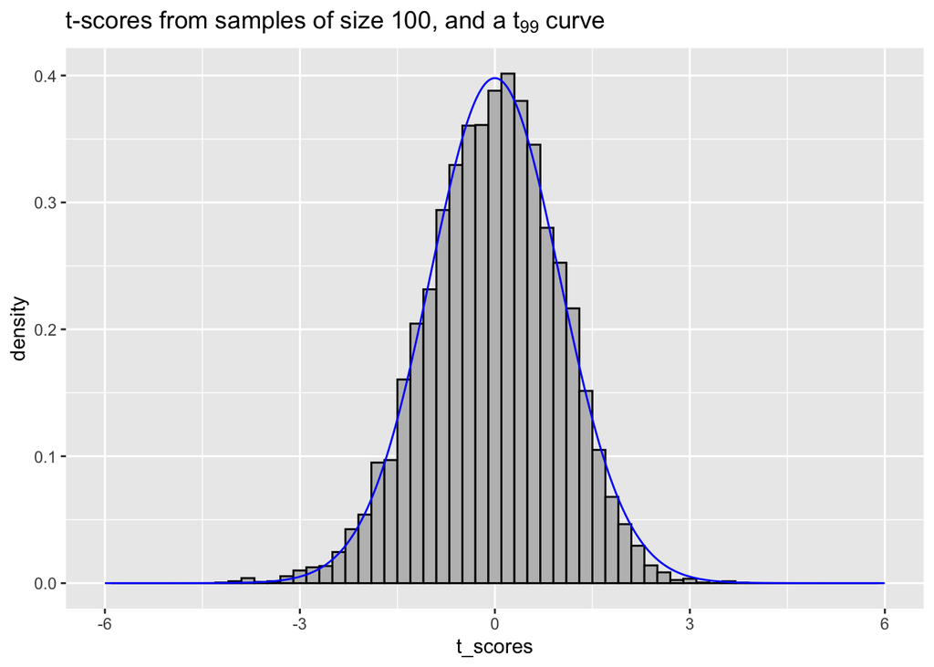

```r
trials<-10000
mu = mean(pop)
n = 100
t_scores=c()
for (i in 1:trials){
  samp <- sample(pop,n)
  xbar <- mean(samp)
  s <- sd(samp)
  t <- (xbar-mu)/(s/sqrt(n))
 t_scores=c(t_scores,t)
  }

# make a plot
tscore <- data.frame(t_scores)
p <- ggplot(tscore) +
  geom_histogram(aes(x = t_scores, y = ..density..),
                 binwidth = .2, fill = "grey", color = "black")
x <- seq(-6,6,.01)
y <- dt(x,n-1)
df<-data.frame(x,y)
p + geom_line(data = df, aes(x = x, y = y), color = "blue") + xlim(-6,6) +
  ggtitle(expression(paste("t-scores from samples of size 100, and a ", t[99]," curve")))
```